# Segmentación de Clientes Bancarios mediante Técnicas de Análisis Multivariado

BD-165 · Modelos Estadísticos Avanzados · Colegio Universitario de Cartago

Grupo 8: Mariana Méndez Pérez, Luis Diego Montero Vargas, Josué Redondo Gómez, Claret Rodríguez Jiménez, Nadin Rojas López

13 de agosto de 2026

# 1 Introducción

Los bancos manejan grandes volúmenes de información sobre sus clientes, pero identificar patrones de comportamiento dentro de esa información no siempre es sencillo a simple vista. Este proyecto aplica técnicas de análisis multivariado para descubrir si existen grupos naturales de clientes según su perfil financiero y demográfico, sin partir de ninguna categoría predefinida.

**Pregunta de análisis:** ¿Existen grupos naturales de clientes según su perfil financiero (puntaje crediticio, edad, antigüedad, balance, número de productos, salario), y esos grupos tienen relación con que el cliente abandone el banco o no?

El objetivo es doble: primero, identificar y caracterizar esos perfiles de cliente mediante técnicas de agrupamiento; segundo, validar si los grupos encontrados de forma no supervisada (sin usar la variable de fuga) coinciden con patrones reales de abandono, lo cual tendría valor práctico para el banco a la hora de diseñar estrategias de retención.

# 2 Descripción de la base de datos

- **Fuente:** [Bank Customer Churn Dataset](https://www.kaggle.com/datasets/shrutimechlearn/churn-modelling), disponible públicamente en Kaggle.
- **Tamaño original:** 10,000 observaciones (clientes), 14 variables.

Las variables originales son: RowNumber, CustomerId, Surname (identificadores, sin valor analítico), CreditScore (puntaje crediticio), Geography (país de residencia), Gender (género), Age (edad), Tenure (años como cliente del banco), Balance (saldo en cuenta), NumOfProducts (cantidad de productos bancarios contratados), HasCrCard (si el cliente tiene tarjeta de crédito o no), IsActiveMember (si el cliente es miembro activo del banco), EstimatedSalary (salario anual estimado) y Exited (si el cliente abandonó el banco; no se usa para el agrupamiento, se reserva para la validación final).

Dado que la mayoría de las variables relevantes para el análisis son numéricas (puntaje crediticio, edad, antigüedad, balance, número de productos y salario), este proyecto aplica tres técnicas de agrupamiento: K-means, K-medoids (PAM) y escalamiento multidimensional (MDS).

## 2.1 Preparación del entorno

Antes de trabajar con los datos, se cargan las librerías de R necesarias para el análisis: tidyverse para la manipulación general de datos, cluster para aplicar la técnica de K-medoids (PAM), factoextra para visualizar los agrupamientos, y GGally para explorar las relaciones entre variables.

```r
# install.packages(c("tidyverse", "cluster", "factoextra", "GGally"))
library(tidyverse)
library(cluster)     # pam()
library(factoextra)  # fviz_cluster(), fviz_nbclust()
library(GGally)       # ggpairs()
```

```r
datos <- read.csv("../data/Churn_Modelling.csv")

str(datos)
```

```
## 'data.frame':    10000 obs. of  14 variables:
##  $ RowNumber      : int  1 2 3 4 5 6 7 8 9 10 ...
##  $ CustomerId     : int  15634602 15647311 15619304 15701354 15737888 15574012 15592531 15656148 15792365 15592389 ...
##  $ Surname        : chr  "Hargrave" "Hill" "Onio" "Boni" ...
##  $ CreditScore    : int  619 608 502 699 850 645 822 376 501 684 ...
##  $ Geography      : chr  "France" "Spain" "France" "France" ...
##  $ Gender         : chr  "Female" "Female" "Female" "Female" ...
##  $ Age            : int  42 41 42 39 43 44 50 29 44 27 ...
##  $ Tenure         : int  2 1 8 1 2 8 7 4 4 2 ...
##  $ Balance        : num  0 83808 159661 0 125511 ...
##  $ NumOfProducts  : int  1 1 3 2 1 2 2 4 2 1 ...
##  $ HasCrCard      : int  1 0 1 0 1 1 1 1 0 1 ...
##  $ IsActiveMember : int  1 1 0 0 1 0 1 0 1 1 ...
##  $ EstimatedSalary: num  101349 112543 113932 93827 79084 ...
##  $ Exited         : int  1 0 1 0 0 1 0 1 0 0 ...
```

```r
dim(datos)
```

```
## [1] 10000    14
```

Primero se carga el archivo Churn_Modelling.csv en el objeto datos. Con la función str() se revisa la estructura interna del dataset: el tipo de cada variable (entero, texto o numérico) y algunos de sus primeros valores. Esto permite ver, por ejemplo, que Geography y Gender son variables de texto (categóricas), mientras que CreditScore, Age, Balance y las demás son numéricas.

Con dim() se obtienen las dimensiones del dataset: 10,000 filas (una por cada cliente) y 14 columnas (una por cada variable)

## 2.2 Contexto demográfico

```r
round(prop.table(table(datos$Geography)) * 100, 1)
```

```
##
##  France Germany   Spain
##    50.1    25.1    24.8
```

```r
round(prop.table(table(datos$Gender)) * 100, 1)
```

```
##
## Female   Male
##   45.4   54.6
```

```r
round(prop.table(table(datos$HasCrCard)) * 100, 1)
```

```
##
##    0    1
## 29.4 70.6
```

```r
round(prop.table(table(datos$IsActiveMember)) * 100, 1)
```

```
##
##    0    1
## 48.5 51.5
```

```r
round(prop.table(table(datos$Exited)) * 100, 1)
```

```
##
##    0    1
## 79.6 20.4
```

De los 10,000 clientes, la mitad son de Francia (50.1%), y el resto se reparte entre Alemania (25.1%) y España (24.8%). Hay un poco más de hombres que de mujeres (54.6% vs 45.4%). El 70.6% tiene tarjeta de crédito y el 51.5% son miembros activos. De todos los clientes, el 20.4% se fue del banco (`Exited`).

# 3 Exploración y preparación de los datos

En esta sección se revisa la calidad de los datos, se realiza la limpieza necesaria, se exploran las distribuciones de las variables y se preparan los datos para aplicar las técnicas de agrupamiento.

## 3.1 Calidad de los datos

Antes de cualquier análisis, es importante verificar que los datos no tengan duplicados ni valores faltantes, ya que esto podría afectar los resultados.

```r
sum(duplicated(datos))
```

```
## [1] 0
```

```r
colSums(is.na(datos))
```

```
##       RowNumber      CustomerId         Surname     CreditScore       Geography
##               0               0               0               0               0
##          Gender             Age          Tenure         Balance   NumOfProducts
##               0               0               0               0               0
##       HasCrCard  IsActiveMember EstimatedSalary          Exited
##               0               0               0               0
```

No se encontraron filas duplicadas ni valores faltantes en ninguna columna, así que no hubo que imputar nada.

## 3.2 Limpieza

Con los datos ya revisados, se procede a eliminar las variables que no aportan información útil para el análisis.

```r
# RowNumber, CustomerId y Surname son identificadores que no describen
# el comportamiento del cliente
datos_limpios <- datos %>%
  select(-RowNumber, -CustomerId, -Surname)

str(datos_limpios)
```

```
## 'data.frame':    10000 obs. of  11 variables:
##  $ CreditScore    : int  619 608 502 699 850 645 822 376 501 684 ...
##  $ Geography      : chr  "France" "Spain" "France" "France" ...
##  $ Gender         : chr  "Female" "Female" "Female" "Female" ...
##  $ Age            : int  42 41 42 39 43 44 50 29 44 27 ...
##  $ Tenure         : int  2 1 8 1 2 8 7 4 4 2 ...
##  $ Balance        : num  0 83808 159661 0 125511 ...
##  $ NumOfProducts  : int  1 1 3 2 1 2 2 4 2 1 ...
##  $ HasCrCard      : int  1 0 1 0 1 1 1 1 0 1 ...
##  $ IsActiveMember : int  1 1 0 0 1 0 1 0 1 1 ...
##  $ EstimatedSalary: num  101349 112543 113932 93827 79084 ...
##  $ Exited         : int  1 0 1 0 0 1 0 1 0 0 ...
```

Antes de explorar los datos, se eliminaron tres variables que no aportan información sobre el comportamiento del cliente: RowNumber (un simple número de fila), CustomerId (identificador interno del banco) y Surname (apellido del cliente). Estas variables son identificadores únicos de cada persona, no características de su perfil financiero, por lo que no sirven para encontrar patrones o agrupar clientes. Tras esta limpieza, el dataset queda con 10,000 observaciones y 11 variables, listo para explorar sus distribuciones y detectar posibles valores atípicos.

## 3.3 Distribuciones y valores atípicos

A continuación se presentan algunos gráficos para explorar la forma en que se distribuyen las variables numéricas, y así identificar posibles valores atípicos antes de continuar con el análisis.

### 3.3.1 Edad

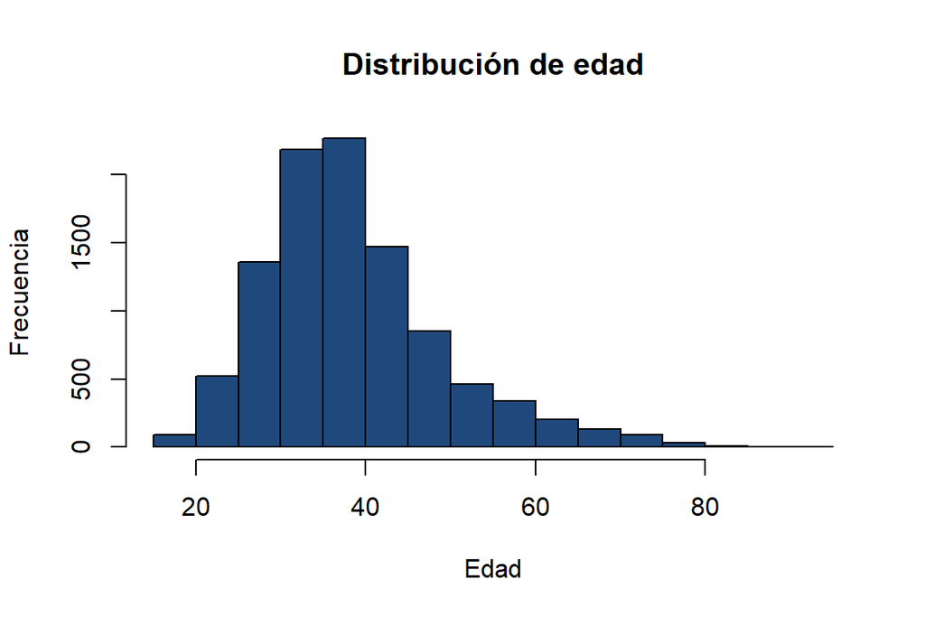

```r
hist(datos_limpios$Age, main = "Distribución de edad",
     xlab = "Edad", ylab = "Frecuencia", col = "#1F497D")
```

Interpretación: La mayoría de los clientes se concentra entre los 30 y 40 años. La distribución tiene una cola hacia la derecha: hay clientes de edades mayores, pero cada vez menos frecuentes conforme aumenta la edad.

### 3.3.2 Balance de cuenta

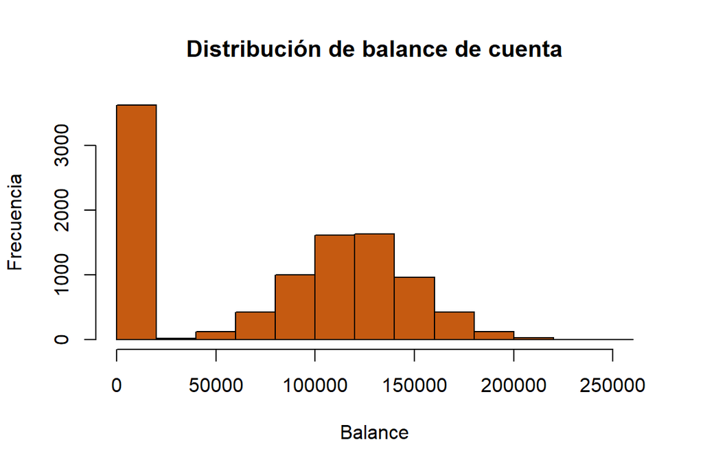

```r
hist(datos_limpios$Balance, main = "Distribución de balance de cuenta",
     xlab = "Balance", ylab = "Frecuencia",col = "#C55A11")
```

```r
mean(datos_limpios$Balance == 0)
```

```
## [1] 0.3617
```

Interpretación: El histograma muestra una barra muy alta en cero: el 36.17% de los clientes tiene el balance de cuenta en cero, como se confirma con el cálculo anterior. El resto de los clientes se distribuye en una forma más parecida a una campana, entre los 50,000 y 200,000, sin otro pico marcado.

### 3.3.3 Puntaje crediticio

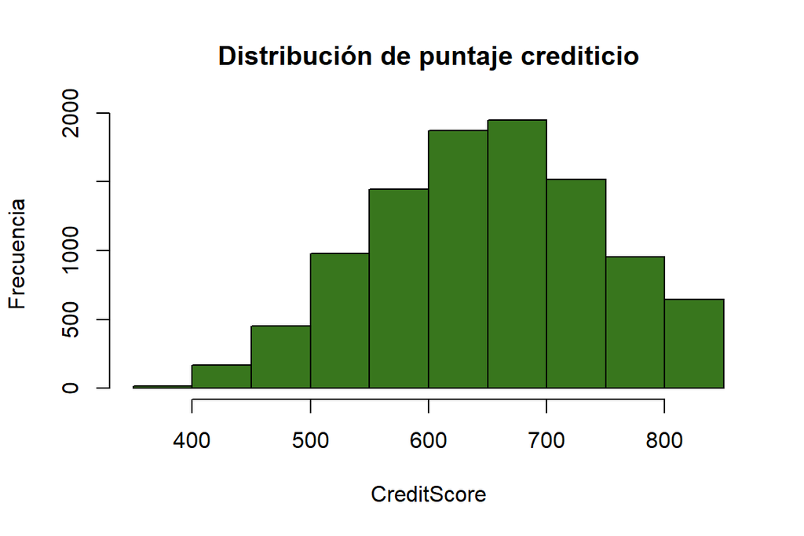

```r
hist(datos_limpios$CreditScore, main = "Distribución de puntaje crediticio",
     xlab = "CreditScore",ylab = "Frecuencia", col = "#38761D")
```

Interpretación: El puntaje crediticio se distribuye de forma bastante simétrica, con la mayor concentración de clientes en el rango medio, similar a una distribución normal.

### 3.3.4 Salario estimado

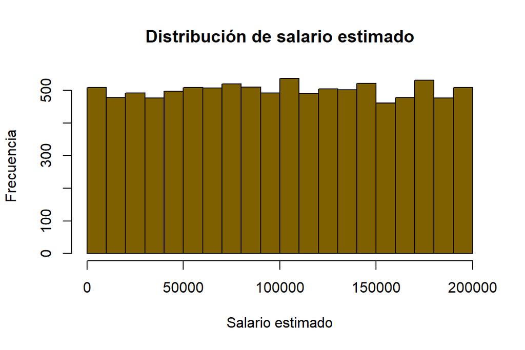

```r
hist(datos_limpios$EstimatedSalary, main = "Distribución de salario estimado",
     xlab = "Salario estimado",ylab = "Frecuencia", col = "#7F6000")
```

Interpretación: El salario estimado se reparte de forma bastante pareja a lo largo de todo su rango, sin un pico claro ni una concentración marcada en algún valor.

### 3.3.5 Boxplots comparativos

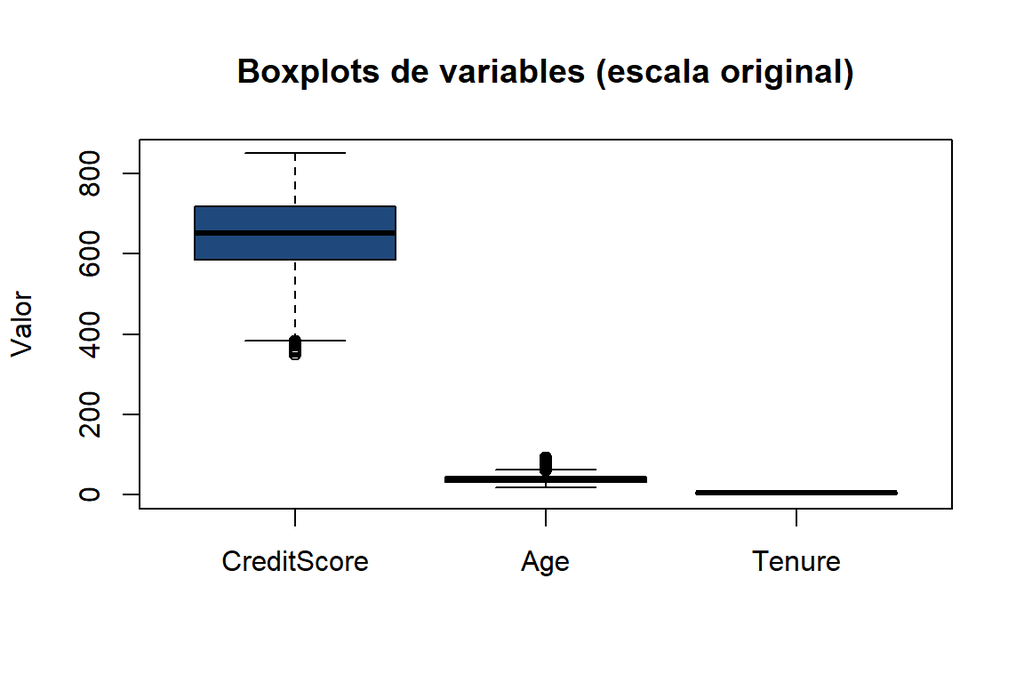

```r
boxplot(datos_limpios[, c("CreditScore", "Age", "Tenure")],
        main = "Boxplots de variables (escala original)",
        ylab = "Valor",
        col = c("#1F497D", "#C55A11", "#38761D"))
```

Al comparar estas tres variables se observa que `Age` es la que más valores atípicos presenta, con varios puntos por encima del bigote superior. `CreditScore` y `Tenure` muestran cajas más compactas, con menos valores extremos visibles.

### 3.3.6 Detección de valores atípicos (regla del IQR)

```r
detectar_outliers <- function(x) {
  q1 <- quantile(x, 0.25)
  q3 <- quantile(x, 0.75)
  iqr <- q3 - q1
  limite_inf <- q1 - 1.5 * iqr
  limite_sup <- q3 + 1.5 * iqr
  sum(x < limite_inf | x > limite_sup)
}

vars_numericas <- datos_limpios %>%
  select(CreditScore, Age, Tenure, Balance, NumOfProducts, EstimatedSalary)

sapply(vars_numericas, detectar_outliers)
```

```
##     CreditScore             Age          Tenure         Balance   NumOfProducts
##              15             359               0               0              60
## EstimatedSalary
##               0
```

Con la regla del IQR se detectaron valores atípicos en tres variables: Age (359 casos, cerca del 3.6% del total, la más relevante), NumOfProducts (60 casos) y CreditScore (15 casos). El resto de las variables (Tenure, Balance, EstimatedSalary) no presentó valores fuera de los límites del IQR. Esto es importante porque justifica usar PAM además de k-means más adelante: PAM aguanta mejor los valores extremos que k-means, especialmente considerando la cantidad de outliers en Age.

## 3.4 Selección de variables para el análisis

Se seleccionaron seis variables numéricas de comportamiento financiero y demográfico: `CreditScore`, `Age`, `Tenure`, `Balance`, `NumOfProducts` y `EstimatedSalary`. Se excluyeron las variables categóricas y la variable `Exited`, que se reserva exclusivamente para la validación posterior, de modo que el agrupamiento se mantenga no supervisado.

```r
vars_cluster <- datos_limpios %>%
  select(CreditScore, Age, Tenure, Balance, NumOfProducts, EstimatedSalary)

exited <- datos_limpios$Exited
```

## 3.5 Correlación entre variables

```r
matriz_cor <- cor(vars_cluster)
round(matriz_cor, 2)
```

```
##                 CreditScore   Age Tenure Balance NumOfProducts EstimatedSalary
## CreditScore            1.00  0.00   0.00    0.01          0.01            0.00
## Age                    0.00  1.00  -0.01    0.03         -0.03           -0.01
## Tenure                 0.00 -0.01   1.00   -0.01          0.01            0.01
## Balance                0.01  0.03  -0.01    1.00         -0.30            0.01
## NumOfProducts          0.01 -0.03   0.01   -0.30          1.00            0.01
## EstimatedSalary        0.00 -0.01   0.01    0.01          0.01            1.00
```

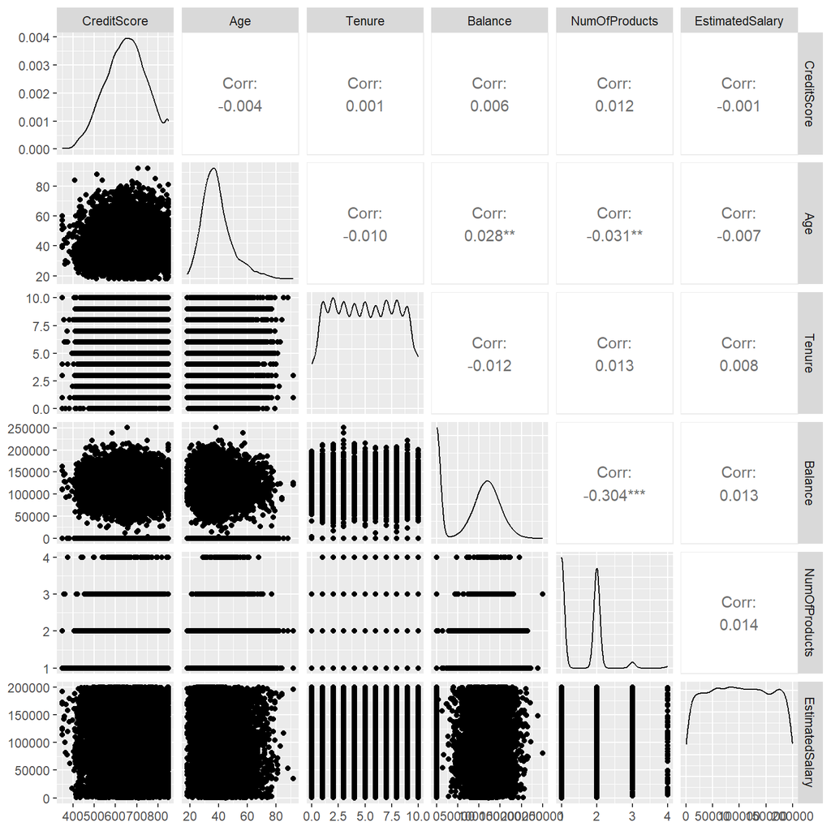

```r
ggpairs(vars_cluster)
```

Interpretación: El gráfico ggpairs() muestra, en la diagonal, la forma de cada variable por separado, y en los paneles de abajo, la relación entre cada par de variables. Se confirma que la mayoría de las relaciones son dispersas, sin un patrón claro, lo cual coincide con las correlaciones bajas calculadas antes. La relación más visible es entre Balance y NumOfProducts, donde se nota que los clientes con más productos tienden a tener menos balance en cuenta, aunque tampoco es una relación muy fuerte.

## 3.6 Escalado

Como último paso antes de aplicar las técnicas de agrupamiento, se escalan las variables seleccionadas para que todas tengan el mismo peso en el cálculo de distancias.

```r
datos_esc <- scale(vars_cluster)

round(colMeans(datos_esc), 2)
```

```
##     CreditScore             Age          Tenure         Balance   NumOfProducts
##               0               0               0               0               0
## EstimatedSalary
##               0
```

```r
round(apply(datos_esc, 2, sd), 2)
```

```
##     CreditScore             Age          Tenure         Balance   NumOfProducts
##               1               1               1               1               1
## EstimatedSalary
##               1
```

Como las variables están en escalas muy distintas (por ejemplo `Balance` llega a valores de miles, mientras `Tenure` va de 0 a 10), hay que escalarlas antes de calcular distancias, igual que se hizo en clase con `clima_estaciones.csv`. Después de escalar, todas quedan con media 0 y desviación 1, como se confirma abajo.

Con los datos limpios, seleccionados y escalados (objeto datos_esc), se procede a aplicar las tres técnicas de agrupamiento: K-means, K-medoids (PAM) y escalamiento multidimensional (MDS).

# 4 Modelos aplicados

## 4.1 K-means

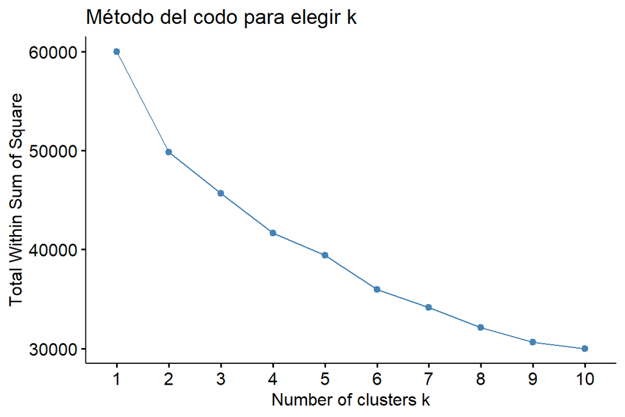

```r
set.seed(123)
fviz_nbclust(datos_esc, kmeans, method = "wss", k.max = 10) +
  labs(title = "Método del codo para elegir k")
```

Se agruparon los 10,000 clientes en 3 grupos según su comportamiento financiero (puntaje crediticio, edad, antigüedad, balance, productos, salario), usando K-means. El modelo no sabe nada de si el cliente se fue del banco o no — solo mira los números y encuentra grupos parecidos entre sí.

**Los 3 grupos que salieron:**

| Grupo | Cuántos clientes | Cómo son |
| --- | --- | --- |
| 1 | 3,196 | Clientes antiguos (7.6 años en promedio), con buen balance en cuenta, pero pocos productos contratados |
| 2 | 3,559 | Clientes con balance casi en cero, pero son los que más productos tienen contratados |
| 3 | 3,245 | Clientes nuevos (2.3 años en promedio), también con buen balance, pero pocos productos |

```r
set.seed(123)
modelo_km <- kmeans(datos_esc, centers = 3, nstart = 25)
modelo_km
```

[output not shown]

[output cut: 281 more lines]

```r
# Asignación de cada cliente a su grupo
table(modelo_km$cluster)
```

```
##
##    1    2    3
## 3196 3559 3245
```

```r
# Perfil de cada grupo (en las variables originales, sin escalar)
datos_kmeans <- vars_cluster
datos_kmeans$Grupo <- factor(modelo_km$cluster)

aggregate(. ~ Grupo, data = datos_kmeans, FUN = mean)
```

```
##   Grupo CreditScore      Age   Tenure   Balance NumOfProducts EstimatedSalary
## 1     1    649.8977 39.62234 7.605444 114489.77      1.288173       106510.57
## 2     2    651.4625 37.98764 5.121101  10447.06      1.974431        98850.15
## 3     3    650.1263 39.25639 2.340524 111484.90      1.281356        95126.95
```

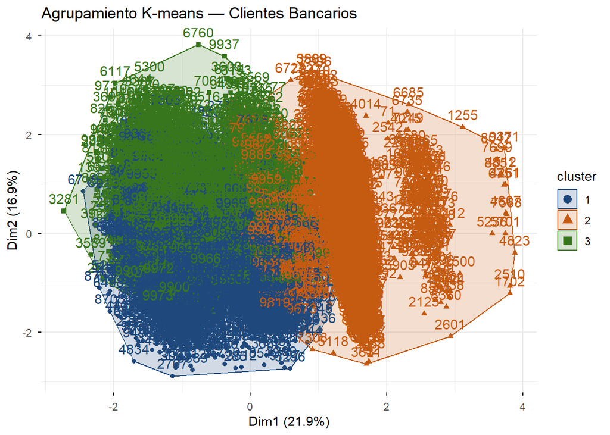

```r
# Visualización
fviz_cluster(modelo_km,
             data = datos_esc,
             palette = c("#1F497D", "#C55A11", "#38761D"),
             ellipse.type = "convex",
             ggtheme = theme_minimal(),
             main = "Agrupamiento K-means — Clientes Bancarios")
```

**Observaciones**

El K-means encontró tres perfiles de cliente que se diferencian principalmente por **cuánto dinero tienen guardado** y **qué tan viejos son como clientes del banco**:

- **Grupo 1 (azul):** clientes leales de toda la vida — llevan años con el banco y tienen buen saldo, pero pocos productos contratados.
- **Grupo 2 (naranja):** clientes con la cuenta casi vacía, pero son los que más productos tienen contratados con el banco.
- **Grupo 3 (verde):** clientes nuevos — llevan poco tiempo, pero ya llegaron con buen saldo, aunque igual que el Grupo 1 tienen pocos productos.

Esto es útil porque el banco podría tratar diferente a un cliente nuevo con plata (Grupo 3) que a uno que ya lleva años (Grupo 1) — antes todos se veían igual, y ahora se pueden separar en estos tres perfiles.

## 4.2 K-medoids (PAM)

A diferencia de K-means, PAM (Partitioning Around Medoids) elige como centro de cada grupo a un cliente real de la base de datos, no un promedio matemático. Esto lo hace más robusto frente a los valores atípicos identificados en `Age` y `NumOfProducts`, donde el IQR detectó 359 y 60 casos extremos respectivamente. Para la realización se empleó k = 3, el cual es el número de grupos elegido con el método del codo.

```r
set.seed(123)
pam_fit <- pam(datos_esc, k = 3)

# Clientes elegidos como medioides (representantes reales de cada grupo)
pam_fit$medoids
```

```
##      CreditScore         Age       Tenure    Balance NumOfProducts
## [1,] -0.09858743  0.10280510 -0.004425736  0.4112229    -0.9115379
## [2,]  0.02556767 -0.08789254 -0.004425736  0.6055112     0.8076962
## [3,] -0.09858743 -0.37393901 -0.004425736 -1.2257864     0.8076962
##      EstimatedSalary
## [1,]     0.009508354
## [2,]    -0.183712734
## [3,]    -0.120696408
```

```r
# Asignación de cada cliente a su grupo
table(pam_fit$clustering)
```

```
##
##    1    2    3
## 4799 2153 3048
```

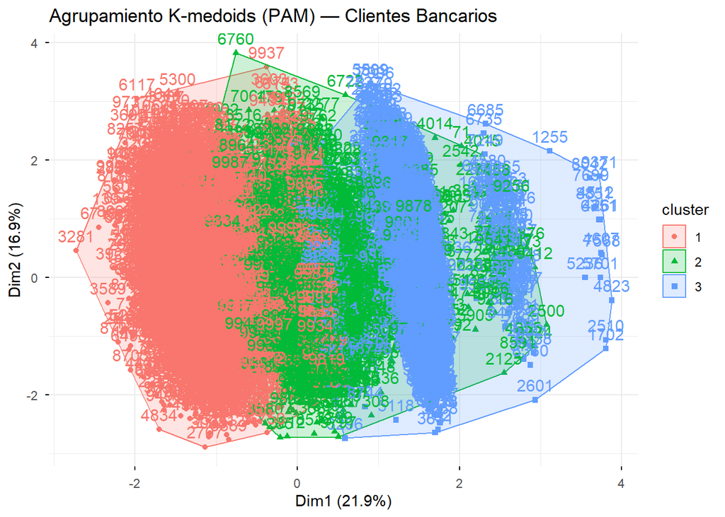

```r
# Visualización de los grupos
fviz_cluster(pam_fit,
             data      = datos_esc,
             ellipse.type = "convex",
             main      = "Agrupamiento K-medoids (PAM) — Clientes Bancarios",
             ggtheme   = theme_minimal())
```

Lo que se observa:

Cluster 1 (rojo): El más grande y disperso, ubicado hacia la izquierda. Agrupa la mayoría de clientes y tiene alta variabilidad interna, lo que sugiere perfiles más heterogéneos. Cluster 2 (verde): Posicionado al centro. Hay traslape considerable con el rojo, lo que indica que estos clientes comparten características con ambos grupos vecinos. Cluster 3 (azul): Se desplaza claramente hacia la derecha en Dim1, lo que sugiere que este grupo se distingue de los demás principalmente en las variables que más peso tienen en esa dimensión.

## 4.3 Escalamiento multidimensional (MDS)

Cmdscale() toma una matriz de distancias euclidianas y produce una configuración en pocas dimensiones que conserva de la mejor manera posible esas distancias originales, permitiendo un mapa interpretable.

```r
vars <- c("CreditScore","Age","Tenure","Balance","NumOfProducts","EstimatedSalary")

# Perfil promedio de cada cluster de K-means, en variables ESCALADAS
# (mismas unidades que se usaron para formar los clusters)

perfiles_km <- aggregate(datos_esc[, vars],
                          by = list(Grupo = modelo_km$cluster),
                          FUN = mean)
rownames(perfiles_km) <- paste("Grupo", perfiles_km$Grupo)

perfiles_km
```

```
##         Grupo  CreditScore         Age      Tenure    Balance NumOfProducts
## Grupo 1     1 -0.006529683  0.06679570  0.89643430  0.6090619    -0.4161016
## Grupo 2     2  0.009660192 -0.08907134  0.03744637 -1.0583586     0.7637371
## Grupo 3     3 -0.004163870  0.03190319 -0.92396784  0.5609048    -0.4278212
##         EstimatedSalary
## Grupo 1      0.11163747
## Grupo 2     -0.02156289
## Grupo 3     -0.08630232
```

Matriz de distancias entre los 3 perfiles (número pequeño = perfiles parecidos, número grande = muy distintos):

```r
d <- dist(perfiles_km[, vars])
d
```

```
##          Grupo 1  Grupo 2
## Grupo 2 2.225414
## Grupo 3 1.832136 2.232747
```

```r
mds <- cmdscale(d, k = 2, eig = TRUE)
mds$points
```

```
##               [,1]        [,2]
## Grupo 1  0.6670665  0.92065362
## Grupo 2 -1.3547348 -0.00928671
## Grupo 3  0.6876684 -0.91136691
```

```r
round(mds$GOF, 3)  # goodness of fit: qué tan bien 2 dimensiones representan las distancias
```

```
## [1] 1 1
```

Como validación posterior (no usada para construir el mapa), calculamos la tasa de fuga real de cada grupo:

```r
tasa_fuga <- round(prop.table(table(Grupo = modelo_km$cluster, Exited = exited),
                               margin = 1)[, "1"] * 100, 1)
tasa_fuga
```

```
##    1    2    3
## 23.2 14.4 24.2
```

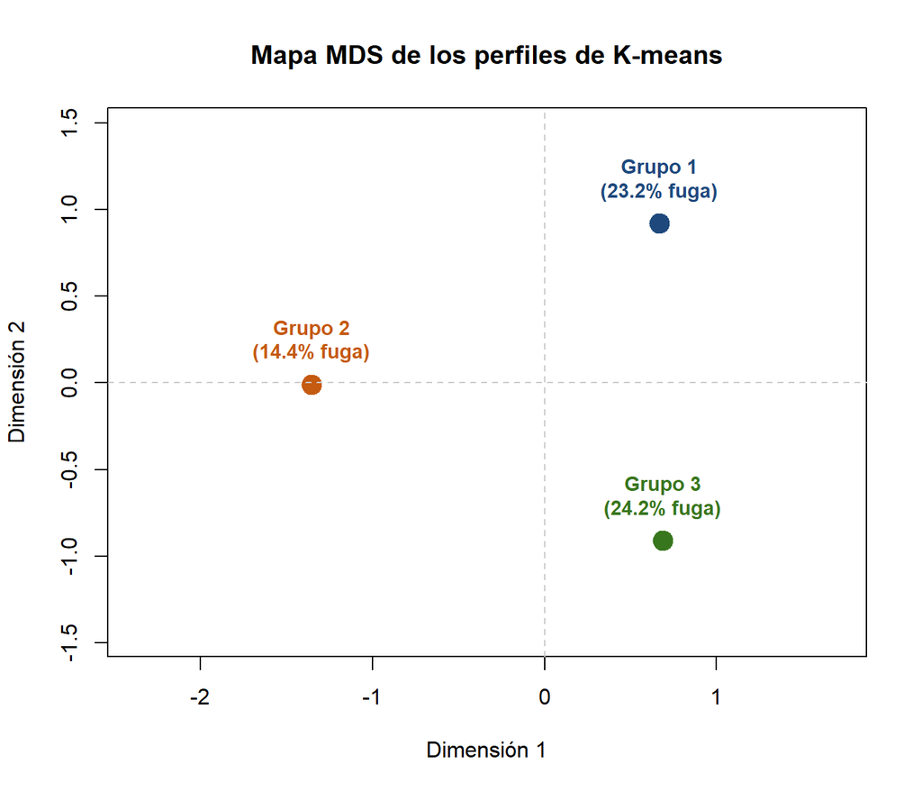

```r
# Márgenes de los ejes con padding extra para que quepan las etiquetas
rango_x <- range(mds$points[,1])
rango_y <- range(mds$points[,2])
pad_x <- diff(rango_x) * 0.5
pad_y <- diff(rango_y) * 0.3

colores_grupo <- c("#1F497D", "#C55A11", "#38761D")

plot(mds$points[,1], mds$points[,2],
     xlim = rango_x + c(-pad_x, pad_x),
     ylim = rango_y + c(-pad_y, pad_y),
     pch  = 19,
     cex  = 2,
     col  = colores_grupo,
     xlab = "Dimensión 1", ylab = "Dimensión 2",
     main = "Mapa MDS de los perfiles de K-means")

etiquetas <- paste0(rownames(perfiles_km), "\n(", tasa_fuga, "% fuga)")

text(mds$points[,1], mds$points[,2],
     labels = etiquetas,
     col    = colores_grupo,
     pos    = 3,        # coloca el texto ARRIBA del punto, no encima
     offset = 1,
     cex    = 0.9,
     font   = 2)

abline(h = 0, v = 0, col = "gray80", lty = 2)  # líneas de referencia opcionales
```

El mapa MDS confirma, desde una perspectiva geométrica, la estructura de tres perfiles identificada por K-means. La Dimensión 1 separa claramente al Grupo 2 de los Grupos 1 y 3 , lo cual coincide con la variable que más distingue a ese grupo: balance de cuenta casi en cero pero mayor cantidad de productos contratados. La Dimensión 2, por su parte, separa al Grupo 1 del Grupo 3, reflejando la diferencia en antigüedad entre ambos: el Grupo 1 son clientes de larga data (~7.6 años en promedio) y el Grupo 3 son clientes recientes (~2.3 años).

## 4.5 MDS

El escalamiento multidimensional aportó una perspectiva complementaria: en vez de agrupar clientes individuales como K-means y PAM, permitió visualizar geométricamente las distancias entre los tres perfiles que K-means ya había encontrado. El mapa mostró que la Dimensión 1, asociada principalmente al balance de cuenta y la cantidad de productos contratados, separa claramente al Grupo 2 de los Grupos 1 y 3, mientras que la Dimensión 2, asociada a la antigüedad del cliente, separa al Grupo 1 (clientes antiguos) del Grupo 3 (clientes nuevos). Al cruzar esta configuración con la tasa de fuga real, se observó que la separación en la Dimensión 1 coincide con una diferencia notable en la fuga (14.4% en el Grupo 2 frente a 23-24% en los otros dos), mientras que la separación en la Dimensión 2 no se traduce en diferencias relevantes de fuga entre clientes antiguos y nuevos. Esto confirma, desde un ángulo distinto al de K-means y PAM, que la variable que más distingue a los grupos en el espacio (balance y productos) es también la que más se relaciona con la retención.

En conjunto, las tres técnicas convergen en una misma conclusión desde ángulos distintos: existe una segmentación real de los clientes bancarios, y esa segmentación está relacionada con la fuga. K-means y PAM coinciden en el número de grupos, aunque difieren en cómo los reparten; el MDS, por su parte, confirma visualmente que la dimensión asociada al balance y la cantidad de productos es la que mejor diferencia a los clientes en términos de riesgo de fuga, por encima de la antigüedad — reforzando la recomendación práctica de enfocar la retención en el número de productos contratados más que en el tiempo que el cliente lleva en el banco.

# 5 Discusión

```r
# Tabla cruzada: grupo de K-means vs. si el cliente se fue del banco
tabla_validacion <- table(Grupo = modelo_km$cluster, Exited = exited)
tabla_validacion
```

```
##      Exited
## Grupo    0    1
##     1 2454  742
##     2 3048  511
##     3 2461  784
```

```r
# Porcentaje de fuga dentro de cada grupo
round(prop.table(tabla_validacion, margin = 1) * 100, 1)
```

```
##      Exited
## Grupo    0    1
##     1 76.8 23.2
##     2 85.6 14.4
##     3 75.8 24.2
```

# 6 Conclusiones